# **Chapter 1** Anatomy I: Body Segments, Joints and Muscles

- Body Segments
  - Upper limb
  - Lower limb
  - Trunk
- Joints
- Muscles

# Body Segments: Bones, segments and groups

Back to Table of Contents

A typical human body has [approximately 200 bones](https://en.wikipedia.org/wiki/List_of_bones_of_the_human_skeleton). In this textbook, only approximately 10 bones will be discussed.

Instead of focussing on individual bones, this textbook will focus primarily on **segments**. Nevertheless, to understand segments, it is important to know which bones belong to which segments.

- **Bones**:
  - A bone is a close-to-rigid structure in our body to which muscles and/or other soft tissues attach.
  - Bones define our bodies' overall structure.
  - Bones transmit forces.
  - Specific anatomical terms exist for all bones.
- **Segments**:
  - A segment consists of a bone and its surrounding soft tissue.
  - A segment's soft tissue can move with respect to the segment's bone.
  - Intra-segment soft tissue movement is usually much smaller than than inter-segment movement.
- **Groups**:
  - A group is a collection of multiple bones or multiple segments
- In Biomechanics:
  - Bone names, segment names and group names are all commonly used.
  - If someone says the anatomical bone name (e.g. "humerus"), they are usually referring to the bone, and not to the segment.
  - If someone uses the common English name (e.g. "upper arm"), they are usually referring to the segment, and not to the bone.
- This course will deal primarily with **segments** and **groups**, but will also occasionally use **bone names**.

## Upper limb

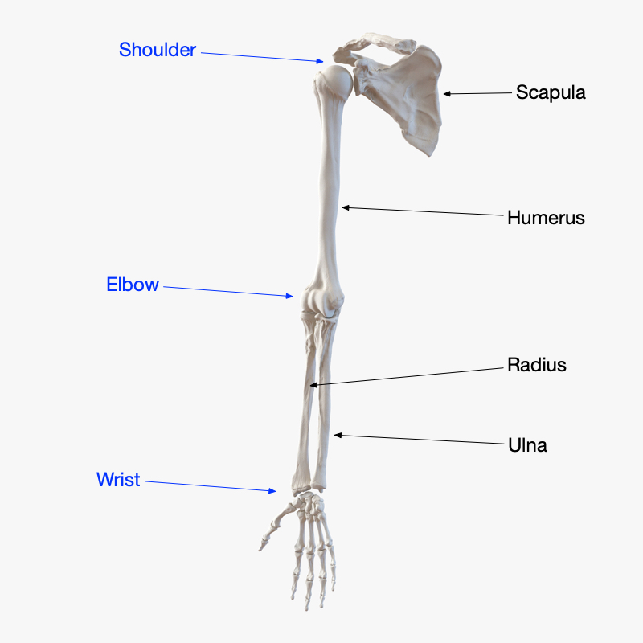

| Bone name [anatomical] | Common English name | Type |
| --- | --- | --- |
| Scapula | Shoulder OR Shoulder Blade | Bone & Segment |
| Humerus | Upper Arm | Bone & Segment |
| Radius | *(None)* | Bone |
| Ulna | *(None)* | Bone |
| Radius & Ulna | Lower Arm OR Forearm | Segment & Group |
| Humerus & Radius & Ulna | Arm OR Upper Limb | Group |
| Scapula & Humerus & Radius & Ulna & (hand and wrist bones) | Upper Limb | Group |

## Lower limb

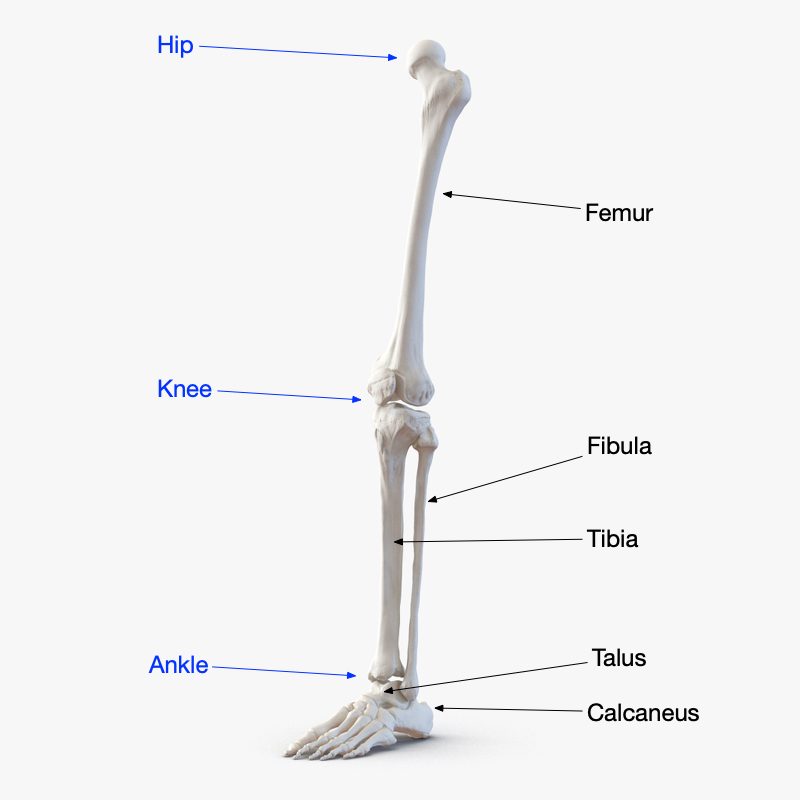

| Bone name [anatomical] | Common English name | Type |
| --- | --- | --- |
| Femur | Thigh OR Upper Leg | Bone & Segment |
| Tibia | Shin | Bone |
| Fibula | *(None)* | Bone |
| Calcaneus | Heel | Bone |
| Tibia & Fibula | Lower Leg OR Shank | Segment & Group |
| Calcaneus & (other foot bones) | Foot* | Segment & Group |
| Femur & Tibia & Fibula | Leg | Group |
| Femur & Tibia & Fibula & Calcaneus & (other foot bones) | Lower Limb | Group |

*In Biomechanics, the foot is often modeled as a single rigid segment.

## Trunk

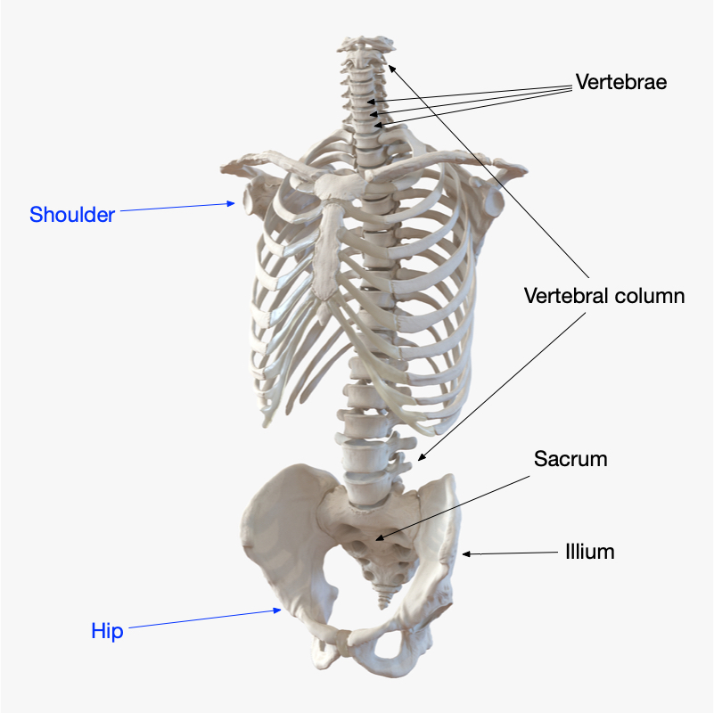

| Bone name [anatomical] | Common English name | Type |
| --- | --- | --- |
| Vertebra* | Back bone | Bone |
| Pelvis | Hip | Bone |
| Sacrum | *(None)* | Bone |
| Illium | *(None)* | Bone |
| Illium & Sacrum | Pelvis | Segment |
| Vertebral column | Spine OR Backbone | Group |
| Trunk OR Torso | Trunk | Group & Segment* |

*"Vertebrae" is the plural of "vertebra" (i.e., one vertebra and two vertebrae).

*In Biomechanics, the trunk is often modeled as a single rigid segment, especially when modeling movements without much vertrbral column flexion (e.g. walking).

# Joints: Main inter-segment joints

Back to Table of Contents

A **joint** allows for relative motion between bones. Joints are anatomical structures, and are usually comprised of cartilage, ligaments, tendons and other soft tissues.

The main joints considered in this textbook are the six listed in the table below.

These joints are indicated in blue font in the figures above.

[output not shown]

# Muscles: Main muscles and muscle groups

Back to Table of Contents

A typical human body contains [over 600 muscles](https://en.wikipedia.org/wiki/List_of_skeletal_muscles_of_the_human_body).

This textbook will consider only muscle groups, and not individual muscles.

The six main muscle groups that will be considered in this textbook are indicated below.

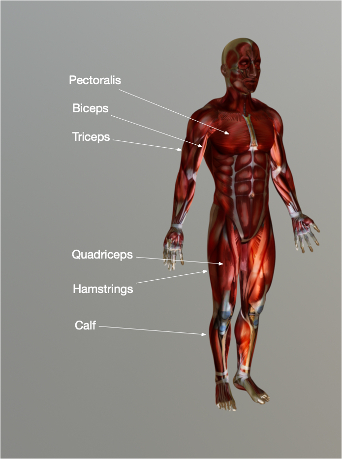

| Common muscle group name | Joint(s) | Main muscles [anatomical names] |
| --- | --- | --- |
| Pectoralis | Shoulder | Pectoralis major, etc. |
| Biceps | Shoulder & Elbow | Biceps brachii, etc. |
| Triceps | Shoulder & Elbow | Triceps brachii, etc. |
| Quadriceps | Hip & Knee | Vastus, etc. |
| Hamstrings | Hip & Knee | Biceps femoris, etc. |
| Calf | Knee & Ankle | Gastrocnemius, etc. |

# Summary

Back to Table of Contents

- This chapter has described the main bones, segments, joints and muscles of the human body
- Bones are near-rigid objects.
- Segments consist of one or more bones and their surrounding soft tissue.
- In Biomechanics, bones, segments, and muscles are often referred to using both common English terms and anatomical terms.
- This main anatomical structures considered in this textbook are those described in this chapter: approximately 10 bones / segments, approximately 6 joints, and approximately 6 muscle groups.